# 🌱 Ruta Rizosfera — Preparatoria

5 estaciones para explorar el suelo, los microorganismos y las matemáticas · MUMAT

1 · Bienvenida 2 · Topología 3 · Rizosfera 4 · Filogenia 5 · Gen 16S

[figure not shown]

🌿 PARADA 1

## Bienvenida al MUMAT

[🏛️ El Hormiguero](https://mumat.matcuer.unam.mx/salas/#3)

¡Bienvenidos al Museo Virtual de Matemáticas! Hoy exploraremos la diversidad microbiana a través de las matemáticas — empezando con un misterio.

👀 ¿Ves las manchitas?

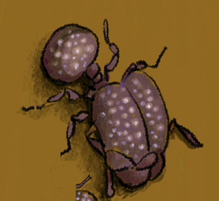

Al visitar El Hormiguero, ¿cuántas hormigas manchadas ves?

🦶👣🦶👣🦶👣🦶👣🦶👣➡️

¡Muy bien! ¡Avanza a la Parada 2! 🐜

[🎬 Microorganismos y hormigas](https://www.youtube.com/shorts/vA6VEFOsmTI)

[figure not shown]

MUMAT

Gato 🐱 🌱 En 1 g de tierra hay más microorganismos que personas en la Tierra

🔮 PARADA 2

## Topología del suelo: hoyos y conexiones

[🏛️ La Cabina](https://mumat.matcuer.unam.mx/salas/#1) ▸ MATEMÁTICAS · TOPOLOGÍA · CARACTERÍSTICA DE EULER

En topología, lo que importa no son las medidas sino la **forma**: cuántos hoyos tiene un objeto. Una esfera (sin hoyos) y una dona (1 hoyo) son *topológicamente distintas*.

Esfera  
g = 0

Dona/Toro  
g = 1

Pretzel  
g = 2

[figure not shown]

Busca este ícono  
en la sala 360°

[figure not shown]

🌱 Conexión con la rizosfera El suelo es una **red de poros y túneles** — topológicamente, ¡un sistema con miles de hoyos! Esos hoyos son el hábitat de millones de bacterias, hongos y artrópodos.

Menor 🔢 🔮 ¡Una taza de café es topológicamente igual a una dona!

🌿 PARADA 3

## La rizosfera viva

[🏛️ El Hormiguero](https://mumat.matcuer.unam.mx/salas/#3) ▸ ECOLOGÍA MICROBIANA · DIVERSIDAD · BIOINFORMÁTICA

La **rizosfera** es la zona del suelo que rodea las raíces — un ecosistema minúsculo pero increíblemente diverso. Puede haber **más de 10 000 especies** bacterianas en un solo gramo de tierra.

[figure not shown]

App **Microbioma**  
Explora la diversidad  
microbiana en el MUMAT

🔗 Laboratorio Agromicrobioma UNAM Investigadores de la UNAM estudian los microbiomas de suelos agrícolas mexicanos para mejorar cultivos sin pesticidas.

[App Diversidad](https://mumat.matcuer.unam.mx/apps/biomat/diversidad/) [Agromicrobioma UNAM ↗](https://agrobiom.matmor.unam.mx/)

Mayor 📐 🦠 La rizosfera tiene 10–100× más bacterias que el suelo sin raíces

🧬 PARADA 4

## El reloj molecular y el COVID-19

[⭐ App Online](https://mumat.matcuer.unam.mx/) ▸ FILOGENIA · GENÓMICA · ÁRBOL DE LA VIDA

Así como clasificamos plantas y animales, **clasificamos microorganismos** por su ADN. El coronavirus fue identificado y clasificado en días gracias a la secuenciación genómica y los **árboles filogenéticos**.

[figure not shown]

App **COVID-19**  
Árbol filogenético de  
variantes del coronavirus

🌳 ¿Qué es un OTU? En microbiología usamos *Operational Taxonomic Units* (OTUs): grupos de microorganismos que comparten ≥97% de similitud genética. ¡Es la definición matemática de "especie" microbiana!

[App Evolución y COVID-19](https://mumat.matcuer.unam.mx/apps/biomat/evolucion/)

Mayor 📐 🧬 El SARS-CoV-2 tiene solo 30,000 bases de ARN — ¡y cambió el mundo!

⚡ PARADA 5

## El gen 16S: 1 gen, millones de species

[⭐ Apps MUMAT](https://mumat.matcuer.unam.mx/) ▸ GENÓMICA · MATEMÁTICAS · ESCALA

El gen **ARNr 16S** tiene ~1 500 pares de bases y está presente en *todas* las bacterias. Al comparar sus secuencias podemos clasificar millones de especies sin necesidad de cultivarlas.

🔢 El poder de los números Con solo 4 letras (A, C, G, U) en 1 500 posiciones existen **4¹⁵⁰⁰ combinaciones posibles** — un número con más de 900 dígitos. La diversidad de la vida cabe en esa matemática.

🌍 Dato impactante La rizosfera de 1 gramo de tierra tiene ~10 000 especies. Para secuenciarlas a todas con el gen 16S necesitarías leer ~**15 millones de bases de ADN**. ¡Eso en menos de 24 horas con tecnología actual!

[Explorar más en MUMAT](https://mumat.matcuer.unam.mx/) [Agromicrobioma UNAM ↗](https://agrobiom.matmor.unam.mx/)

Gato 🐱 🔢 4¹⁵⁰⁰ supera el número de átomos en el universo observable

[figure not shown]